# Virulence index

```r
library(here)
library(tidyverse)
```

```r
library(lubridate)
library(broom)
library(cowplot)
library(scales)
```

# The virulence index

Based on paper *Storms, Zachary J., et al. “The Virulence Index: A Metric for Quantitative Analysis of Phage Virulence.” PHAGE 2019*

## load data

```r
# read this file
xpt.file <- here("data", "virulence-index", "Bacterial_reduction_16hrs_200404.txt")

# number of times plate was read
xpt.reads = grep("Reads", readLines(xpt.file), value = T)%>%
  str_remove(pattern = ".*,") %>% parse_number()

# start line of OD table
start.line = grep("^Time.*A1", readLines(xpt.file))

# end line of OD table
aprox.end.line.n= floor(start.line+xpt.reads)-start.line

# read data and organize it
input <-
  read_tsv(xpt.file,
       skip = start.line-1,
       n_max = aprox.end.line.n-1,
       col_types = cols(Time = "c"))%>%
  # rename temp column
    rename("temp"=2)%>%
  # Convert time to hms
    mutate(Time=lubridate::hms(Time))%>%
    mutate(Time=as.duration(Time))%>%
  # remove empty lines
    filter(Time != 0)
```

In these files there are reads every 2 min. I will average on window of 8 reads.

```r
# window size
win <- 8

#number of points after averaging
n.group <-floor( nrow(input)/win)

# remove last rows so it divides by win
input <- input[1:(win*n.group),]

input.avg <-
  input%>%
  #add grouping variable
    mutate(g=ntile(1:(win*n.group),n.group))%>%
    group_by(g)%>%
    summarise(across(where(is.numeric), ~ mean(.x, na.rm = TRUE)))%>%
  #remove grouping var
    select(-g) %>%
  # convert time to hours
    mutate(Time = Time/3600)

#transform to long format
d <- gather(input.avg, key="well", value = "OD600", colnames(input)[-c(1:2)])

#add metadata
meta <- read_csv(here("data", "virulence-index","layout.csv"))

d <-merge(d, meta)
```

Examine data a curves

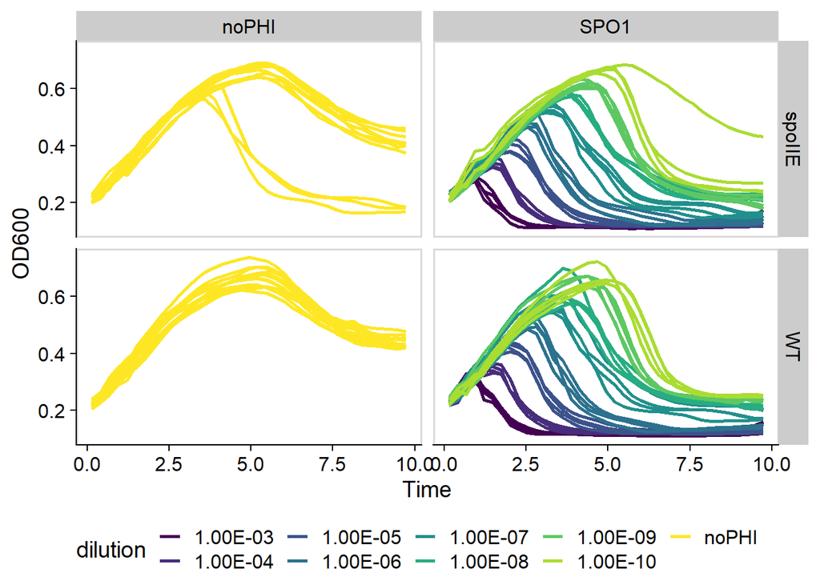

```r
d%>%
  filter(dilution != "Blank")%>%
  filter(Time<10)%>%
  ggplot(aes(x=Time, y=OD600))+
  geom_line(aes(group=well,color=dilution), size=1)+
  facet_grid(host~phage)+
  theme_cowplot()+
  panel_border()+
  scale_color_viridis_d()+
    theme(legend.position = "bottom")
```

Overall, there is a good dilution dependence in the timing of bacterial growth reduction (i.e. lysis). There appear to be a few phage contaminated controls, and perhaps a single well that sis not receive phage in the highest dilution on host $\Delta$spoIIE. Which wells are these?

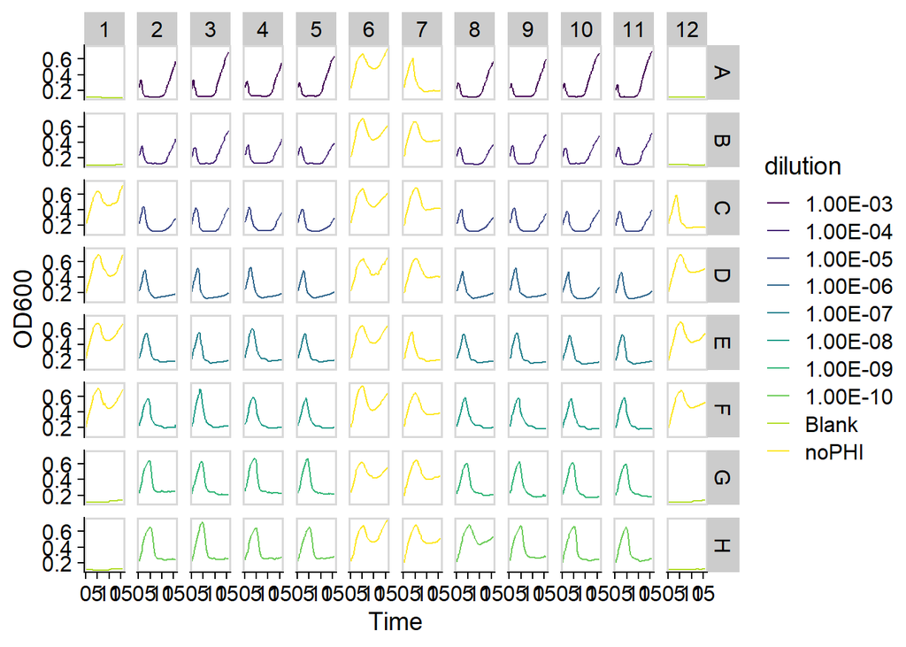

```r
d%>%
  group_by(well)%>%
  ggplot(aes(x=Time, y=OD600))+
    geom_line(aes(color=dilution))+
    facet_grid(row~col)+
  theme_cowplot()+
  panel_border()+
  scale_color_viridis_d()
```

* Phage contaminated control wells: A7, E7 and C12  
* Well H8 may have not received phage. we will remove those wells:

```r
contam.wells <- c("A7", "E7" , "C12", "H8")

d <-
  d%>%
  filter(!well %in%contam.wells)

meta <-
  meta%>%
  filter(!well %in%contam.wells)
```

## Calculating the virulence index

Folowing Storms et. al.

> 1. establish limit of integration:  
>    It is important to stress how the establishment of the limit of integration plays a significant role in the assessment of virulence. This limit should be set as the onset of stationary phase in the phage-free control. This provides a consistent reference for integration that can be easily identified for any phage–host system and restricts measurements to the period of cell growth — a necessary condition for productive infection for many phages. Moreover, it ensures that the range of the virulence measurements is well distributed, as discussed hereunder. In general, we recommend establishing the limit of integration as the time at which the slope of OD630 over time reaches ≤0.03 h.

### Determining the integration limit

Doing this can be done in 2 ways:  
A.using ‘growthcurver’ to find no-phage carrying capacity (k)

```r
library(growthcurver)

k.noPHI <-
  input %>%
  # make time in hours
  mutate (Time = as.numeric(Time)/3600)%>%
  #focus on time before OD decline
  filter(Time < 7) %>%
  # select non-infected data
  select(c("Time", meta$well[meta$phage=="noPHI"]))%>%
  # derive growth parameters with "growthcurver"
  SummarizeGrowthByPlate(., bg_correct = "none")%>%
  select(well = sample, k)

# for each of the non-infected wells we now find the time it reached carrying capacity

# add column to store time
k.noPHI$Time.k <- NA

for(i in seq(k.noPHI$well)){
  w <- k.noPHI$well[i]
  k <- k.noPHI$k[i]
  tmp <-
    d%>%
    filter(well==w)
  k.noPHI$Time.k[i] <-
    tmp$Time[which(tmp$OD600>k)[1]]

}
#remove loop vars
rm(tmp, i,w,k)
# use the median time found
int.limit <- median(k.noPHI$Time.k, na.rm = TRUE)
int.limit
```

```
## [1] 4.669444
```

B. by visual inspection of plots  
First I will look at the change in OD over time. Storms et al. recommend >establishing the limit of integration as the time at which the slope of OD630 over time reaches ≤0.03 h

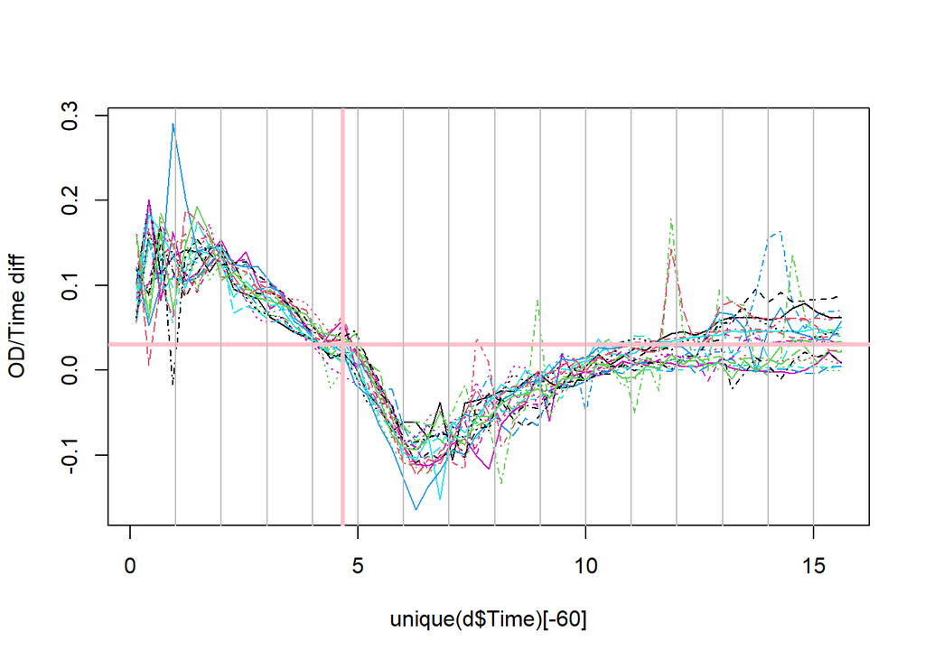

```r
time.diff <- diff(d$Time[1:2])

d %>%
  filter(phage=="noPHI")%>%
  split(.$well)%>%
  map_df("OD600")%>%
  map_df(diff)%>%
    map_df(function(x) x/time.diff)-> tmp

matplot(x= unique(d$Time)[-60],tmp, type="l", ylab = "OD/Time diff")
abline(h=0.03, col="pink", lwd=3)
abline(v=c(1:floor(max(d$Time))), col="grey")
abline(v = int.limit, col="pink", lwd=3)
```

The integration limit found by first methods matches also the second method. So we use 4.7 hrs as the integration limit. How does that look?

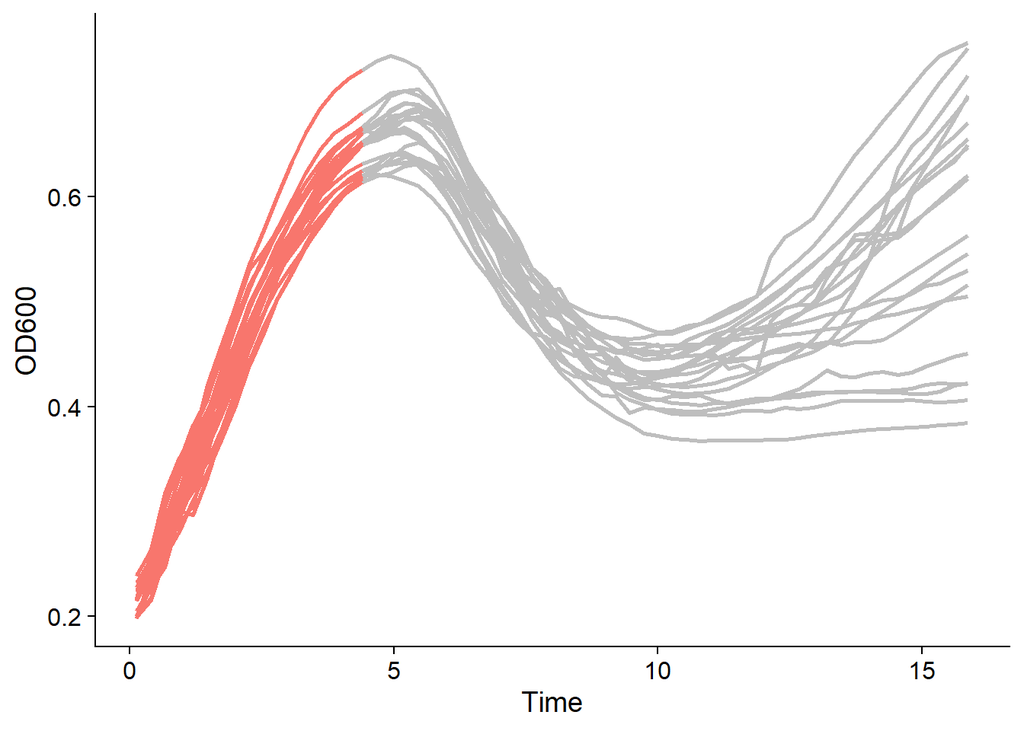

```r
d%>%
  filter(phage=="noPHI")%>%
  filter(Time<int.limit)%>%
  ggplot(aes(x=Time, y=OD600, group = well))+
  geom_line(data=filter(d,phage=="noPHI"), color="grey", size=1)+
  geom_line(aes(color=as.factor(dilution)), size=1)+
  theme_cowplot()+
    theme(legend.position = "none")
```

Looks right!

## Choosing the dilution range

Need to make sure to use only dilutions in which all wells got phage.

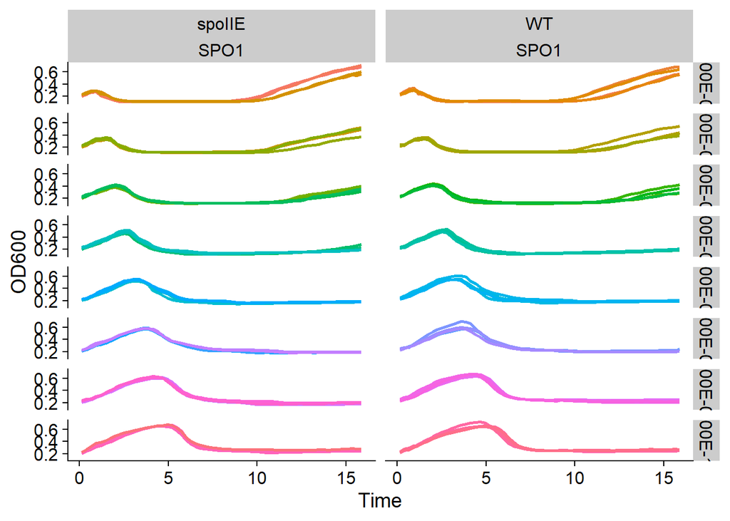

```r
phage.vol <- 0.1 #ml
# the following titer was measured by plaque assay
init.titer <- 1.5e11 #PFU/ml
max.dilut <- 1/(init.titer*phage.vol)

# verify visually
d%>%
  filter(host != "Blank")%>%
  filter(dilution != "Blank")%>%
  # filter(Time<int.limit)%>%
  filter(phage!="noPHI")%>%
  # filter(dilution<=max.dilut)%>%
  ggplot(aes(x=Time, y=OD600))+
  geom_line(aes(color=well), size=1)+
  facet_grid(dilution~host+phage)+
  theme_cowplot()+
    theme(legend.position = "none")
```

All the dilutions can be used.

Plot of lysis within the time of integration

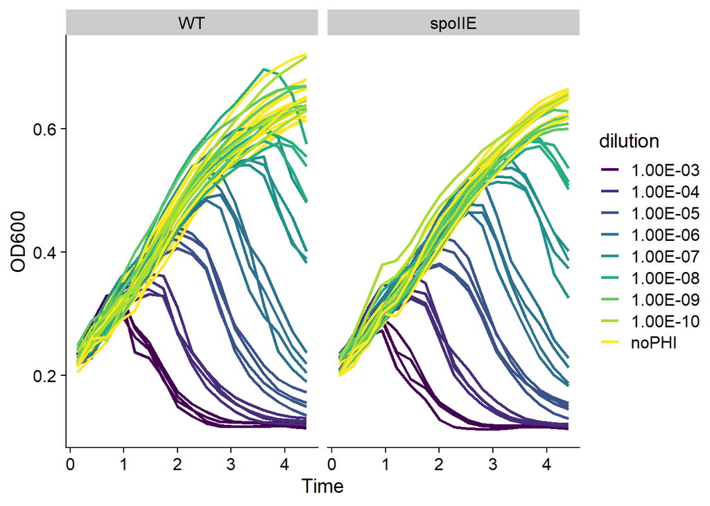

```r
d%>%
  filter(host != "Blank")%>%
  filter(dilution != "Blank")%>%
  filter(Time<int.limit)%>%
  filter(!grepl("COL",dilution))%>%
  # filter(phage!="noPHI")%>%
  # filter(dilution<=max.dilut)%>%
  ggplot(aes(x=Time, y=OD600))+
  geom_line(aes(group=well,color=dilution), size=1)+
  facet_wrap(~fct_rev(host))+
  theme_cowplot()+
  scale_color_viridis_d()
```

## Integrate the area under curve

Storms et al.:

> areas underneath the optical density versus time curves were calculated using the trapezoid rule for each well, from the time of infection to the time corresponding to the onset of stationary phase in the phage-free control

```r
library(caTools) #needed for trapezoids
# add column for area under the curve
meta$auc <- NA

for(i in seq(meta$well)){
  if(meta$host[i]=="Blank") next
  # get data for a single well within integration limit
  tmp <-
    d%>%
    filter(well==meta$well[i])%>%
    filter(Time<=int.limit)
  # calc. area under the curve
  meta$auc[i] <- trapz(tmp$Time, tmp$OD600)

}
rm(tmp)

# summarize no phage control areas for each colony
sum.noPHI <-
  meta%>%
    filter(host != "Blank")%>%
    filter(phage=="noPHI")%>%
    group_by(host, colony)%>%
    summarise( A0=mean(auc), sd=sd(auc), n=n())
```

Because of phage contamination I dont have non-infected wells of COL1 of the spoIIE host. perhaps I can use the other colonies to estimate this:

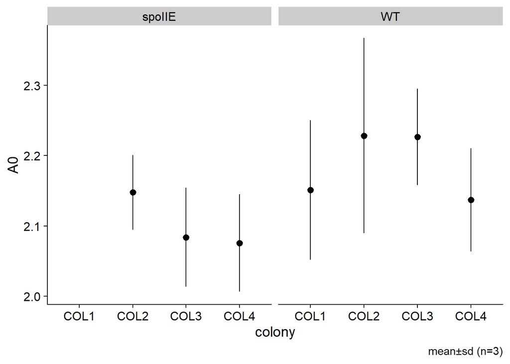

```r
sum.noPHI%>%
  ggplot(aes (x = colony, y = A0))+
  geom_pointrange(aes(ymin = A0-sd, ymax = A0+sd))+
  facet_wrap(~host)+
  theme_cowplot()+
  labs(caption = ("mean±sd (n=3)"))
```

```r
summary(aov(A0 ~ host + colony, data = sum.noPHI))
```

```
##             Df   Sum Sq  Mean Sq F value Pr(>F)
## host         1 0.011958 0.011958  13.327 0.0675 .
## colony       3 0.008363 0.002788   3.107 0.2529
## Residuals    2 0.001795 0.000897
## ---
## Signif. codes:  0 '***' 0.001 '**' 0.01 '*' 0.05 '.' 0.1 ' ' 1
```

There is no significant difference between colonies within host. I will assign COL1 the mean of the 3 other colonies

```r
A0.col1 <-
  sum.noPHI%>%
  filter(host=="spoIIE")%>%
  pull(A0)%>%
  mean()

sum.noPHI <-
  tibble(host = "spoIIE", colony = "COL1", A0 = A0.col1,
         sd = NA, n = NA)%>%
  bind_rows(.,sum.noPHI)
```

Now, we continue with the analysis

```r
# add the non-infected auc of the right host colony to each well
vindex <- merge(meta, sum.noPHI)
# calc. local virulence
vindex$Vi <- 1-(vindex$auc/vindex$A0)
# calculate MOI assuming 2.5e7 CFU/ml
vindex$log.moi <- log10(as.numeric(vindex$dilution)*init.titer/2.5e7)
```

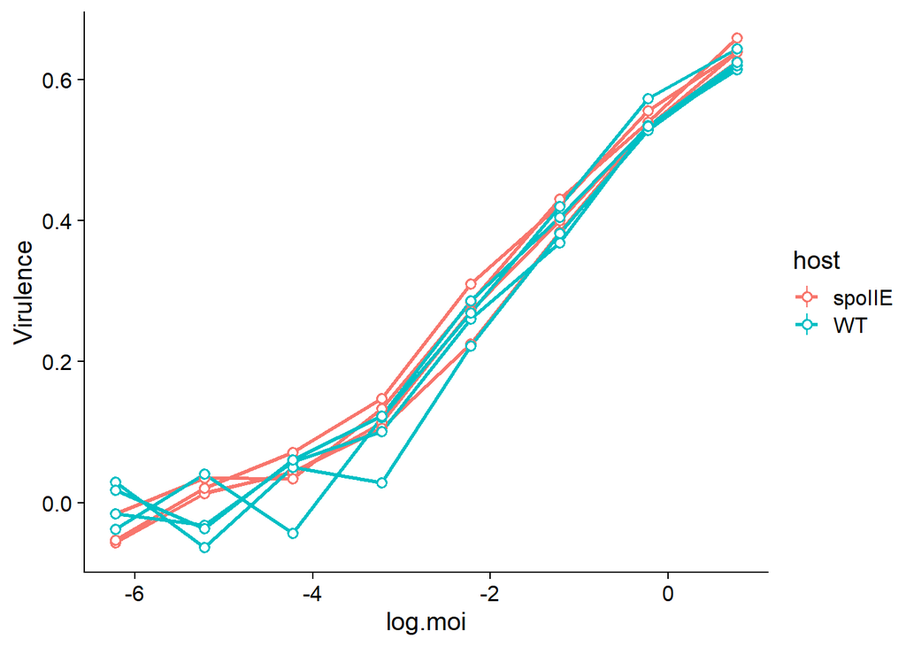

```r
vindex%>%
  filter(phage!="noPHI")%>%
  group_by(host,colony, phage, log.moi)%>%
  summarise( Virulence=mean(Vi), mn=min(Vi), mx=max(Vi), n=n())%>%
  ggplot(aes(log.moi, Virulence))+
  geom_line(aes(color=host, group = interaction(colony,host)), size=1)+
  geom_pointrange(aes(ymin=mn, ymax=mx, color=host ), shape=21, fill="white")+
  # facet_wrap(~host)
  theme_cowplot()
```

## summarize to single value index

Storms et al.:  
>The virulence index is defined as the area under the virulence curve (AP) divided by the theoretical maximum area under the virulence curve (Amax)

**Vp = Ap / Amax**

```r
sum.phi <- vindex%>%
  filter(phage!="noPHI")%>%
  group_by(host,colony, phage)%>%
  summarise(  n=n())
```

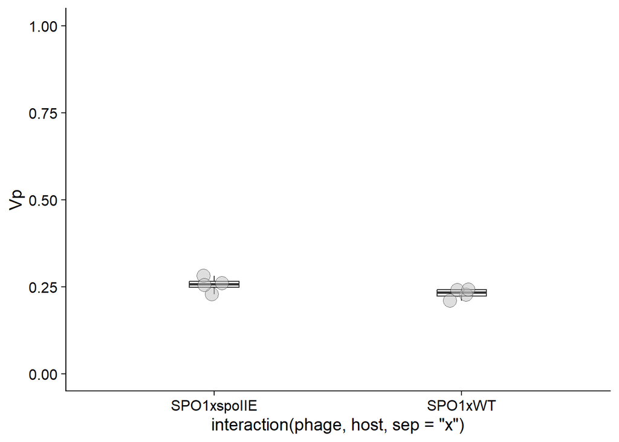

```r
sum.phi$Ap <- NA
sum.phi$Amax <- NA
for(i in seq(nrow(sum.phi))){

  tmp <-
    vindex%>%
    filter(phage!="noPHI")%>%
    filter(host==sum.phi$host[i])%>%
    filter(colony==sum.phi$colony[i])%>%
    filter(phage==sum.phi$phage[i])%>%
    # filter(dilution>=max.dilut)%>%
    arrange(log.moi)
  sum.phi$Ap[i] <- trapz(tmp$log.moi, tmp$Vi)
  sum.phi$Amax[i] <-  trapz(tmp$log.moi,rep(1, nrow(tmp)))

}

rm(tmp)
sum.phi$Vp <- sum.phi$Ap/sum.phi$Amax

sum.phi%>%
  # filter(n==8)%>%
  ggplot(aes(x=interaction(phage,host, sep = "x"), y=Vp))+
  geom_boxplot(width=0.2)+
    geom_jitter(shape=21,#aes(shape=as.factor(colony)),
              height=0, width=0.05,size=5, fill="grey", alpha=0.5)+
  # scale_shape_manual(values=c(15,16,22,21))+
  ylim(0,1)+
  theme_cowplot()
```

## Stats

```r
summary(aov(Vp~host+colony, sum.phi  ))
```

```
##             Df    Sum Sq   Mean Sq F value Pr(>F)
## host         1 0.0013235 0.0013235   2.666  0.201
## colony       3 0.0005586 0.0001862   0.375  0.779
## Residuals    3 0.0014893 0.0004964
```

# No Difference!!

```r
t.test(Vp~host, sum.phi )
```

```
##
##  Welch Two Sample t-test
##
## data:  Vp by host
## t = 1.9692, df = 5.2943, p-value = 0.1028
## alternative hypothesis: true difference in means between group spoIIE and group WT is not equal to 0
## 95 percent confidence interval:
##  -0.007302392  0.058751974
## sample estimates:
## mean in group spoIIE     mean in group WT
##            0.2558996            0.2301748
```

# presentable plot

Plot of virulence index

```r
#summary stats
d.plot.sum <-
  sum.phi%>%
  mutate(host = str_replace(host, "spoIIE", "dSpoIIE")) %>%
  group_by(host) %>%
  summarise(n = n(),
            m = mean(Vp),
            sem = sd(Vp)/sqrt(n))

#plot
p1 <-
sum.phi%>%
  mutate(host = str_replace(host, "spoIIE", "dSpoIIE")) %>%
  ggplot(aes(x = fct_rev(host), y = Vp))+
  geom_jitter(shape = 21, size = 1.5, fill = "grey",
              alpha = 0.5, height = 0, width = 0.1)+
  geom_errorbar(data = d.plot.sum,
                aes(y = m, ymin = m-sem, ymax = m+sem),
                size = .5, width = 0.2)+
  geom_point(data = d.plot.sum, aes(y=m),
                size = 2, shape = 21, fill = "black")+
  theme_cowplot()+
  panel_border(color = "black", size = 1.5)+
  scale_x_discrete(labels=c("WT" = "wild-type","dSpoIIE" = expression(Delta*italic(spoIIE))))+
  scale_shape_manual(values = c(21,22,24))+
  theme(strip.background = element_blank(),
          strip.text = element_text(face = "bold"))+
  ylim(0,NA)+
  xlab("host strain")+
  ylab("Phage Virulence (Vp)")
  # ggsave(here("plots","Vir-index.png"), width = 4, height = 3)
```

Plot comparing lysis curves

```r
p2 <-
d%>%
  filter(dilution != "Blank")%>%
  filter(Time<=8)%>%
  mutate(dilution = str_replace(dilution, "noPHI", "no phage")) %>%
  mutate(host = str_replace(host, "spoIIE", "dSpoIIE")) %>%
# average replicates
  group_by(Time, host, dilution) %>%
  summarise(n = n(), m = mean(OD600), v = sd(OD600)/sqrt(n)) %>%
#plot
  ggplot(aes(x=Time, y=m))+
  geom_vline(xintercept = int.limit, linetype = 3, alpha = 0.35)+
  geom_linerange(aes(ymin = m-v, ymax = m+v, color=host),
                 size=.5, show.legend = F)+
  geom_line(aes(color=host), size=.5)+
  facet_wrap(~dilution, dir = "v")+
  theme_cowplot()+
  panel_border(color = "black", size = 1.5)+
    theme(legend.position = c(.01, .95),
          legend.title = element_blank(),
          strip.background = element_blank(),
          strip.text = element_text(face = "bold"),
          axis.title.y = element_blank())+
  scale_color_grey(guide = guide_legend(reverse = TRUE), #name = "host strain",
                   labels=c("WT" = "wild-type","dSpoIIE" = expression(Delta*italic(spoIIE))))+
  ylab("OD600")+
  xlab("Time (hrs)")
  # ggsave(here("plots","lysis.png"), width = 4, height = 5)
```

Put the plots together

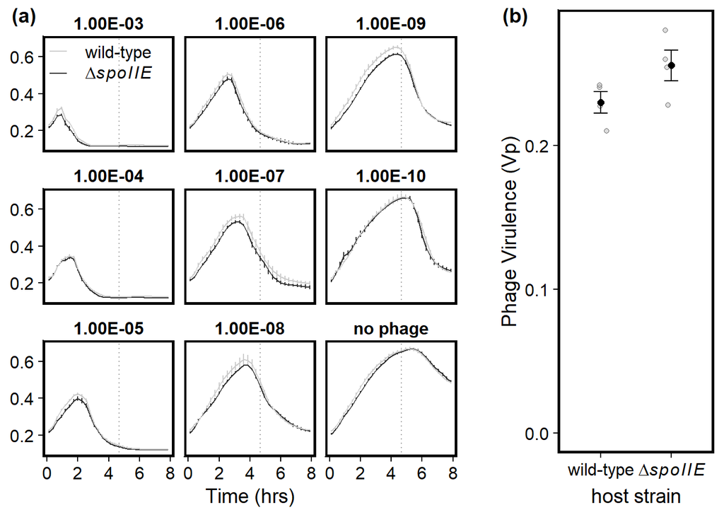

```r
plot_grid(p2,NULL, p1,
          rel_widths = c(2,0.1,1),
          labels = c("(a)","", "(b)"),
          nrow = 1) -> p
  ggsave(here("plots","virulence.png"),p, width = 8, height = 5, bg = "white")
  p
```